# Supplementary Information for Intra-tumoral Budding

Trinh et al

20/2/2018

This document contains the code used to generate plots and conduct statistical analysis for **Tumor budding is associated with the mesenchymal colon cancer subtype and RAS/RAF mutations: a study of 1525 colorectal cancers with Consensus Molecular Subgroup (CMS) data**

# Data: Summary of the cohort(s) of interest

Four cohorts were used in this study: CAIRO, CAIRO2, LUMC and AMC. Here, we load the clinical information and budding information for each cohort:

## Budding distribution

| Feature | CAIRO | LUMC | CAIRO2 | AMC |
| --- | --- | --- | --- | --- |
| Mean no. buds | 30 | 4 | 43.67 | 6.04 |
| SD | 39.9 | 8.73 | 71.52 | 7.83 |
| Median | 15 | 0 | 18 | 3 |
| Min no. buds | 0 | 0 | 0 | 0 |
| Max no buds | 246 | 54 | 650 | 33 |
| Count <=5 | 152 | 573 | 139 | 50 |
| Count >5 | 356 | 135 | 348 | 26 |
| No samples | 508 | 708 | 487 | 76 |
| No patients | 504 | 470 | 475 | 76 |
| Mean no cores per patient | 1.01 | 1.51 | 1.03 | 1 |

Below are plots showing the distribution of buds in each data set:

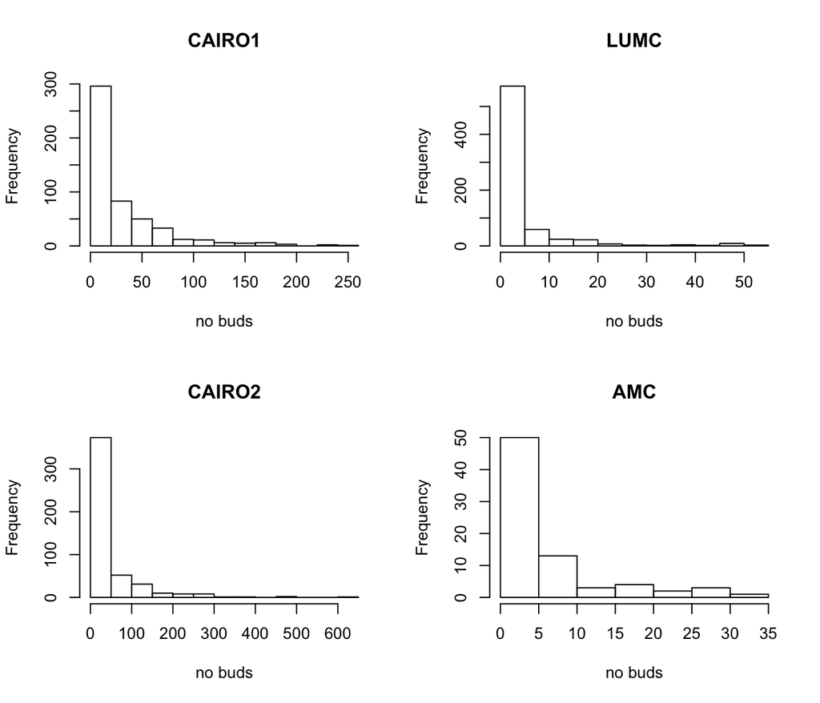

Note that the LUMC cohort where between 1-5 cores are available for each patient: We can compute the mean number of buds per sample and plot the variation vs mean value to look at the consistency between cores:

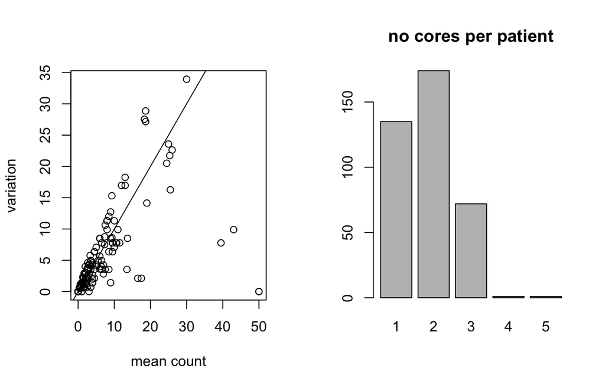

## clincal characteristics

Below is a summary of the clinical characteristics of the cohorts for which there is budding information. This is summarised in **Table 1**

[output not shown]

# Associations with CMS data

Load in the CMS calls from the Cairo1, LUMC and CAIRO 2. Note that Group 1 is CMS2/3 (epithelial), Group3 (CMS4) is mesenhcymal.

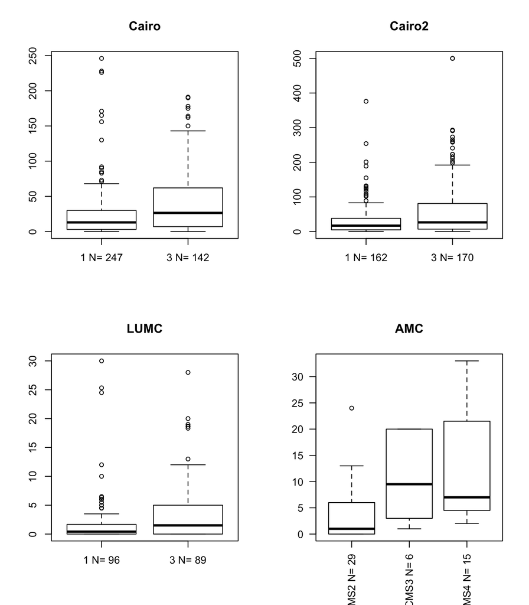

Below is a summary of the CMS data available for each cohort, as well as the budding statistics for each subtype:

| Feat |  | CAIRO | LUMC | CAIRO2 | AMC |
| --- | --- | --- | --- | --- | --- |
| CMS available |  | 401 | 214 | 340 | 76 |
| CMS classifier |  | IHC | IHC | IHC | GeneExp |
| CMS2/3 | no | 247 | 96 | 162 | 36 |
| - | mean | 23.85 | 2.11 | 32.45 | 4.42 |
| - | sd | 35.52 | 4.98 | 48.83 | 6.04 |
| CMS4 | no | 142 | 89 | 170 | 19 |
| - | mean | 41.4 | 3.84 | 59.61 | 11.47 |
| - | sd | 44.71 | 5.59 | 84.83 | 10.8 |

Perform wilcox test between the two groups (compare CCS 1 (epithelial) and CCS3 (mesenchymal):

```
## [1] "CAIRO 1"
```

```
##
##  Wilcoxon rank sum test with continuity correction
##
## data:  Cai1ClinNew$Count[Cai1ClinNew$CMS != 2] by Cai1ClinNew$CMS[Cai1ClinNew$CMS != 2]
## W = 12748, p-value = 7.193e-06
## alternative hypothesis: true location shift is not equal to 0
```

```
## [1] "LUMC"
```

```
##
##  Wilcoxon rank sum test with continuity correction
##
## data:  LeiClinNew$mean[LeiClinNew$CMS != 2] by LeiClinNew$CMS[LeiClinNew$CMS != 2]
## W = 3381.5, p-value = 0.01109
## alternative hypothesis: true location shift is not equal to 0
```

```
## [1] "CAIRO 2"
```

```
##
##  Wilcoxon rank sum test with continuity correction
##
## data:  Cai2ClinNew$no.of.buds[Cai2ClinNew$CMS != 2] by Cai2ClinNew$CMS[Cai2ClinNew$CMS != 2]
## W = 11415, p-value = 0.007036
## alternative hypothesis: true location shift is not equal to 0
```

```
## [1] "AMC (original classifier)"
```

```
##
##  Wilcoxon rank sum test with continuity correction
##
## data:  AMCClinNew$Budding.ITBCC[AMCClinNew$Class != 2] by AMCClinNew$Class[AMCClinNew$Class != 2]
## W = 184.5, p-value = 0.005084
## alternative hypothesis: true location shift is not equal to 0
```

```
## [1] "AMC (CMS classification)"
```

[output not shown]

In all the above cohorts, there is a statistically higher ITBB in CMS4/mesenchymal subtype.

# Survival analysis

## Univariate thresholding

A threshold of 5 is used to discretise between low and high budding.

Print a summary of the survival times including the 95% confidence intervals

| Sample | CAIRO | LUMC | CAIRO2 | AMC |
| --- | --- | --- | --- | --- |
| T<5 | 21.65 (18.64 - 25.88) | NA ( 50 - NA) | 22.18 (18.07 - 26.02) | NA |
| T>=5 | 16.23 (14.61 - 18.15) | 19 (10 - 33 ) | 21.98 (19.84 - 24.48) | NA |

Below are the survival curves, reporting the logrank p value in the univariate case. These are displayed in **Figure2**

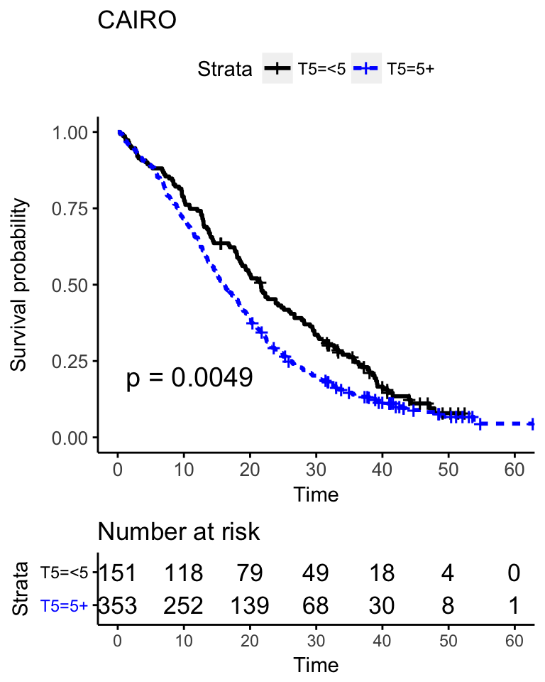

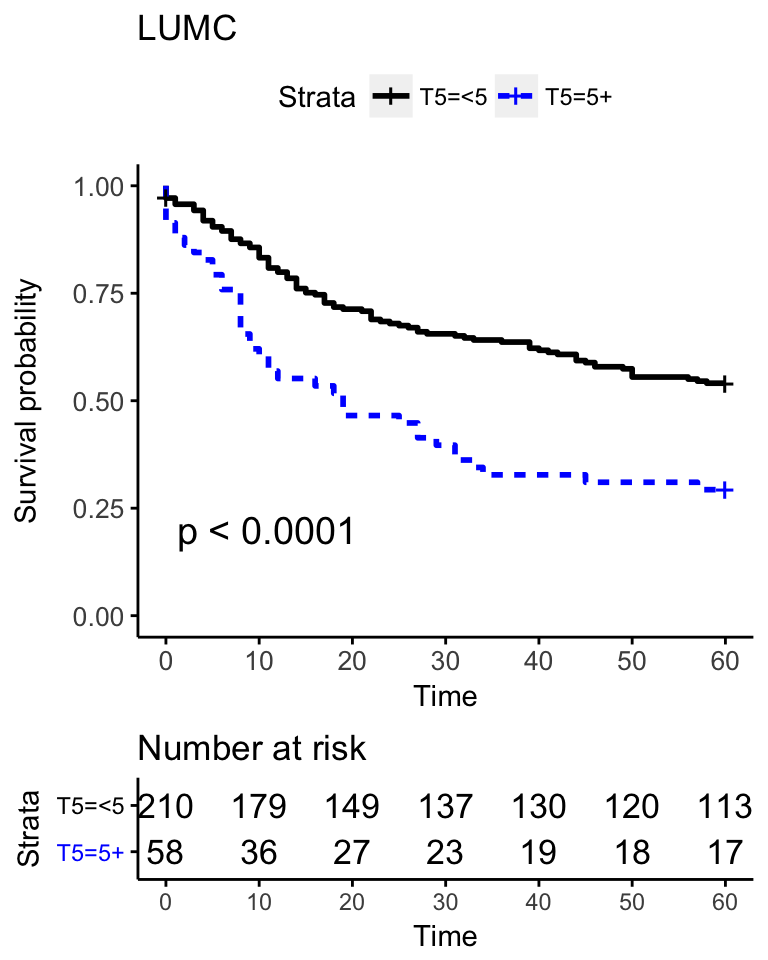

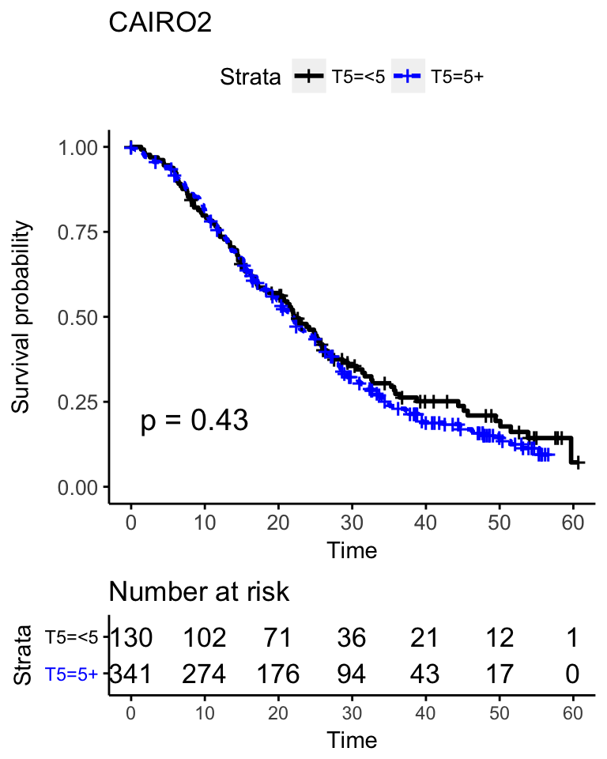

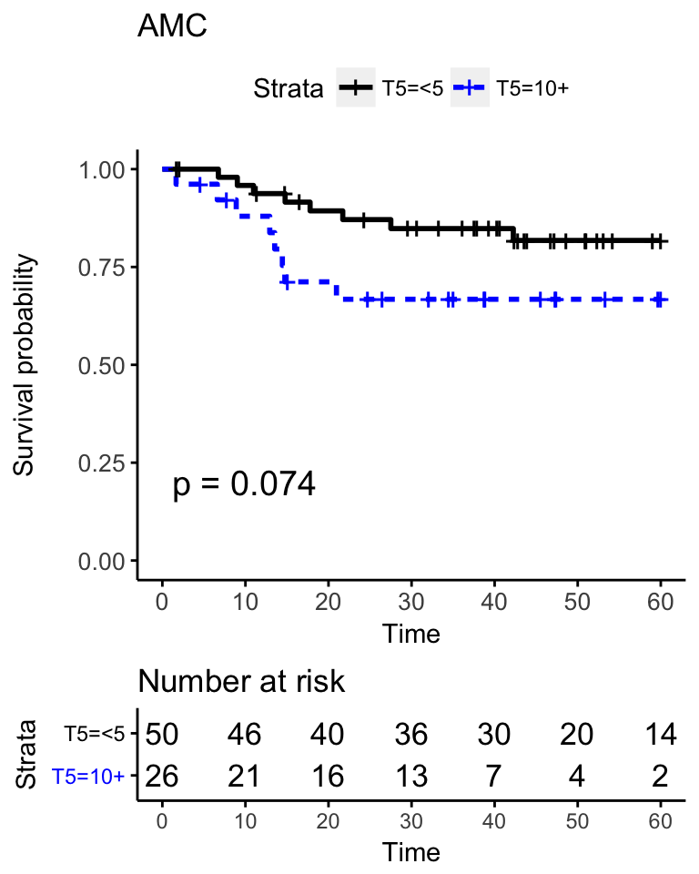

Report the survival output:

| Cohort | HR | CI | logrank P |
| --- | --- | --- | --- |
| CAIRO | 1.34 | 1.09 - 1.65 | 0.0049 |
| LUMC | 2.11 | 1.46 - 3.05 | 0 |
| CAIRO2 | 1.1 | 0.87 - 1.39 | 0.4278 |
| AMC | 2.39 | 0.89 - 6.38 | 0.074 |

## Multivariate cox models

Here, we report the HR using Multivariate cox models adjusting for sex, age stage and treatment arms (where applicable)

Table of the covariates using Threshold of 5:

| Variable |  | CAIRO1 | LUMC | CAIRO2 | AMC |
| --- | --- | --- | --- | --- | --- |
| Budding | low |  |  |  |  |
| - | high | 1.36 (1.11-1.68) | 2.26 (1.53-3.34) | 1.09 (0.86-1.39) | 3.53 (1.15-10.83) |
| Sex | F |  |  |  |  |
| - | M | 1.07 (0.88 - 1.31) | 1.14 (0.81-1.61) | 1.05 (0.85 - 1.3) | 1.16 (0.43 - 3.11) |
| Arm | A |  |  |  |  |
| - | B | 0.88 (0.73 - 1.06) |  | 1.15 (0.93 - 1.42) |  |
| Stage | 1* |  |  |  |  |
| - | 2* |  | 1.58 (0.8 - 3.09) |  | 6.97 (1.66 - 29.33) |
| - | 3 |  | 2.75 (1.4 - 5.41) |  |  |
| - | 4 |  | 8.66 (4.41 - 17.01) |  |  |
| Age |  | 1 (0.99 - 1.01) | 1.03 (1.02 - 1.05) | 1.02 (1 - 1.03) |  |
| Model P |  | 0.0265 | 0 | 0.0557 | 0.0181 |

Note: For the AMC cohort, levels 1 and 2 refer to stage 2A and 2B respectively

We can also visualise this in forest plots (as shown in **Figure 3**)

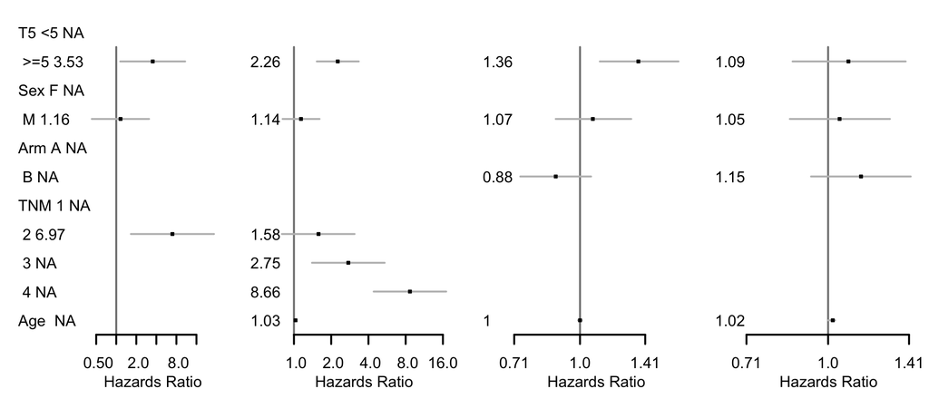

A summary of the number of samples with survival information:

```
## [1] "CAIRO 1"
```

```
##   T5      Geslacht
##  <5:151   F   :181
##  5+:353   M   :322
##           NA's:  1
```

```
## [1] "LUMC"
```

```
##   T5          Sex        TNM
##  <5:210   female:134   1   :42
##  5+: 58   male  :134   2   :99
##                        3   :75
##                        4   :49
##                        NA's: 3
```

```
## [1] "CAIRO 2"
```

```
##   T5      Sex
##  <5:130   F:197
##  5+:342   M:275
```

```
## [1] "AMC"
```

```
##    T5     Sex    stage
##  <5 :50   F:40   IIA:71
##  10+:26   M:36   IIB: 5
```

# Budding as a continuous variable

## Univariate analysis

repeat the above analysis using the raw number of buds. Instead of showing KM plots, indicate the HR of bud count as a continuous variable:

Summary of the hazards ratios

| Cohort | HR | CI | logrank P |
| --- | --- | --- | --- |
| CAIRO | 1.25 | 1.08 - 1.45 | 0.0033 |
| LUMC | 1.89 | 1.33 - 2.69 | 4e-04 |
| CAIRO2 | 1.14 | 0.97 - 1.33 | 0.105 |
| AMC | 1.91 | 0.63 - 5.74 | 0.247 |

## Multivariate analysis

Repeat the same analysis taking into account age, stage and treatment arm

| Variable |  | CAIRO1 | LUMC | CAIRO2 | AMC |
| --- | --- | --- | --- | --- | --- |
| Budding | low |  |  |  |  |
| - | high | 1.27 (1.09-1.48) | 1.92 (1.31-2.83) | 1.15 (0.98-1.36) | 3.1 (0.92-10.52) |
| Sex | F |  |  |  |  |
| - | M | 1.08 (0.89 - 1.32) | 1.11 (0.79-1.56) | 1.05 (0.85 - 1.3) | 1.12 (0.42 - 3) |
| Arm | A |  |  |  |  |
| - | B | 0.87 (0.72 - 1.05) |  | 1.14 (0.92 - 1.4) |  |
| Stage | 1* |  |  |  |  |
| - | 2* |  | 1.71 (0.88 - 3.35) |  | 7.07 (1.63 - 30.57) |
| - | 3 |  | 2.9 (1.48 - 5.67) |  |  |
| - | 4 |  | 8.73 (4.45 - 17.16) |  |  |
| Age |  | 1 (0.99 - 1.01) | 1.03 (1.01 - 1.05) | 1.02 (1 - 1.03) |  |
| Model P |  | 0.0165 | 0 | 0.0208 | 0.0381 |

Plot forest plots of harzards ratios

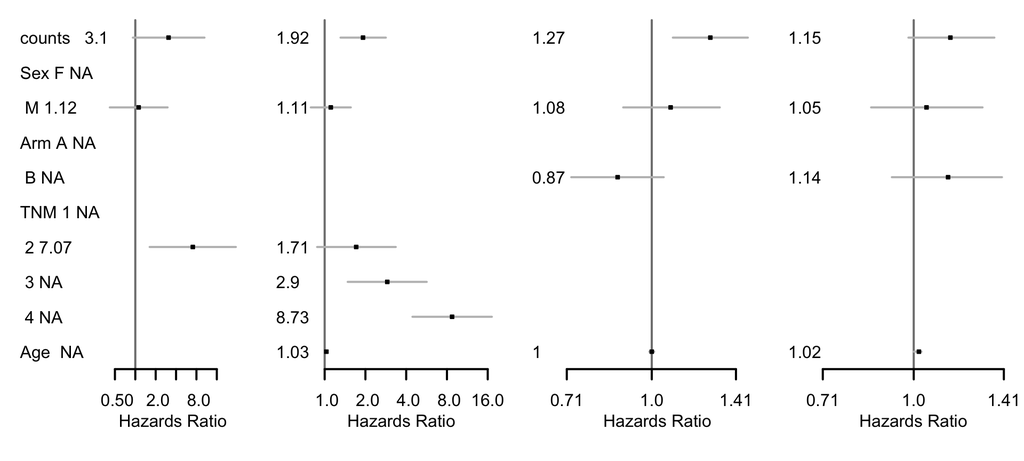

# Treatment outcome (CAIRO cohorts)

Look at the effect of outcome taking into account the treatment used. This is featured in **Supplementary Figure 1**

## Thresholding

Threshold according to T5 and see whether there is an effect on treatment in KM plots. Here we discretise account to both treatment arm as well as Arm into 4 groups of interest

### CAIRO

survival based on thresholding:

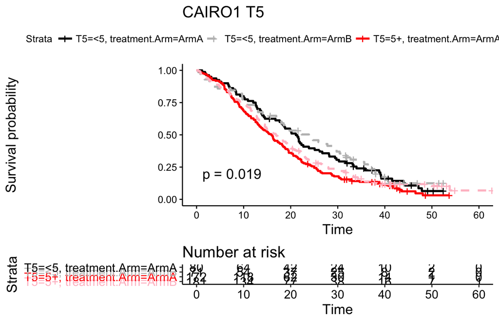

Below, we can run a cox model taking into account age, and sex:

```
## [1] "coxph model: with age, treatment arm, sex"
```

```
## Call:
## coxph(formula = ssCai1 ~ treatment.Arm + T5 + Geslacht + Age,
##     data = Cai1ClinNew)
##
##   n= 503, number of events= 442
##    (1 observation deleted due to missingness)
##
##                        coef exp(coef)  se(coef)      z Pr(>|z|)
## treatment.ArmArmB -0.126828  0.880886  0.095887 -1.323   0.1859
## T55+               0.309174  1.362300  0.106516  2.903   0.0037 **
## GeslachtM          0.070992  1.073573  0.100814  0.704   0.4813
## Age                0.003625  1.003632  0.005161  0.702   0.4825
## ---
## Signif. codes:  0 '***' 0.001 '**' 0.01 '*' 0.05 '.' 0.1 ' ' 1
##
##                   exp(coef) exp(-coef) lower .95 upper .95
## treatment.ArmArmB    0.8809     1.1352    0.7300     1.063
## T55+                 1.3623     0.7341    1.1056     1.679
## GeslachtM            1.0736     0.9315    0.8811     1.308
## Age                  1.0036     0.9964    0.9935     1.014
##
## Concordance= 0.552  (se = 0.015 )
## Rsquare= 0.022   (max possible= 1 )
## Likelihood ratio test= 11.26  on 4 df,   p=0.02378
## Wald test            = 10.94  on 4 df,   p=0.02721
## Score (logrank) test = 11  on 4 df,   p=0.02653
```

We can create forest plots looking at separate treatment arms:

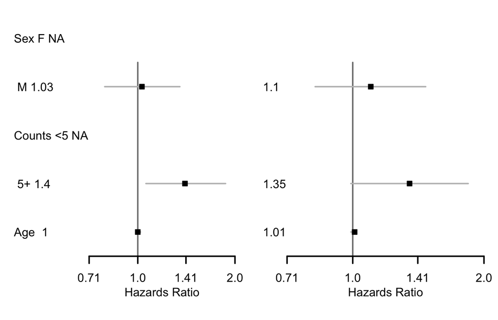

### CAIRO2

Using 5 as the cut off

[figure not shown]

```
## [1] "coxph model: with age, treatment arm, sex"
```

```
## Call:
## coxph(formula = ssCai2 ~ Arm + T5 + Sex + Age, data = Cai2ClinNew)
##
##   n= 454, number of events= 354
##    (18 observations deleted due to missingness)
##
##               coef exp(coef) se(coef)     z Pr(>|z|)
## ArmwCetux 0.137204  1.147062 0.107549 1.276  0.20205
## T55+      0.087667  1.091624 0.121535 0.721  0.47070
## SexM      0.048868  1.050082 0.109420 0.447  0.65515
## Age       0.015712  1.015836 0.006056 2.595  0.00947 **
## ---
## Signif. codes:  0 '***' 0.001 '**' 0.01 '*' 0.05 '.' 0.1 ' ' 1
##
##           exp(coef) exp(-coef) lower .95 upper .95
## ArmwCetux     1.147     0.8718    0.9291     1.416
## T55+          1.092     0.9161    0.8602     1.385
## SexM          1.050     0.9523    0.8474     1.301
## Age           1.016     0.9844    1.0039     1.028
##
## Concordance= 0.548  (se = 0.017 )
## Rsquare= 0.021   (max possible= 1 )
## Likelihood ratio test= 9.53  on 4 df,   p=0.0492
## Wald test            = 9.22  on 4 df,   p=0.0558
## Score (logrank) test = 9.23  on 4 df,   p=0.05571
```

Forest plot looking at separate treatment arms:

```
## [1] "coxph model: with age, treatment arm, sex"
```

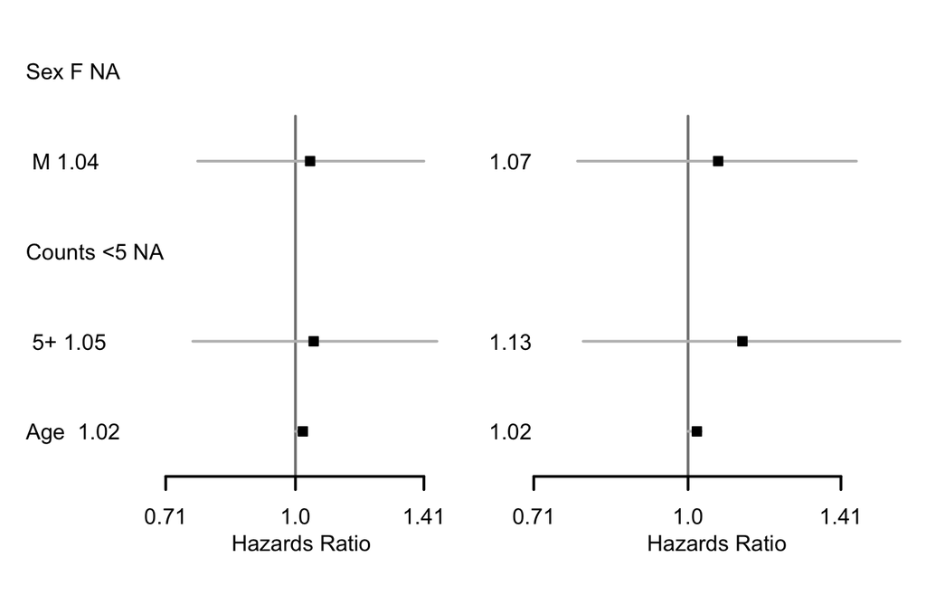

## Continuous variable

As previous analysis has shown that budding counts rather than a strict cut off may have prognostic value, we do the same analysis for predictive value:

### CAIRO

```
## [1] "coxph model: with age, treatment arm, sex"
```

### CAIRO 2

```
## [1] "coxph model: with age, treatment arm, sex"
```

```
## Call:
## coxph(formula = ssCai2 ~ Arm + Sex + Age + log10(no.of.buds +
##     1), data = Cai2ClinNew)
##
##   n= 454, number of events= 354
##    (18 observations deleted due to missingness)
##
##                           coef exp(coef) se(coef)     z Pr(>|z|)
## ArmwCetux             0.128676  1.137322 0.107460 1.197  0.23114
## SexM                  0.051066  1.052392 0.109425 0.467  0.64073
## Age                   0.016087  1.016217 0.006076 2.647  0.00811 **
## log10(no.of.buds + 1) 0.142747  1.153438 0.082256 1.735  0.08267 .
## ---
## Signif. codes:  0 '***' 0.001 '**' 0.01 '*' 0.05 '.' 0.1 ' ' 1
##
##                       exp(coef) exp(-coef) lower .95 upper .95
## ArmwCetux                 1.137     0.8793    0.9213     1.404
## SexM                      1.052     0.9502    0.8492     1.304
## Age                       1.016     0.9840    1.0042     1.028
## log10(no.of.buds + 1)     1.153     0.8670    0.9817     1.355
##
## Concordance= 0.547  (se = 0.017 )
## Rsquare= 0.026   (max possible= 1 )
## Likelihood ratio test= 12.04  on 4 df,   p=0.01706
## Wald test            = 11.58  on 4 df,   p=0.02077
## Score (logrank) test = 11.58  on 4 df,   p=0.02075
```

[figure not shown]

# Effect of KRAS/BRAF mutation

Here, we assess whether there is an association between mutation status and outcome, and we also include KRAS and BRAF status into the cox models:

## Association with ITBB

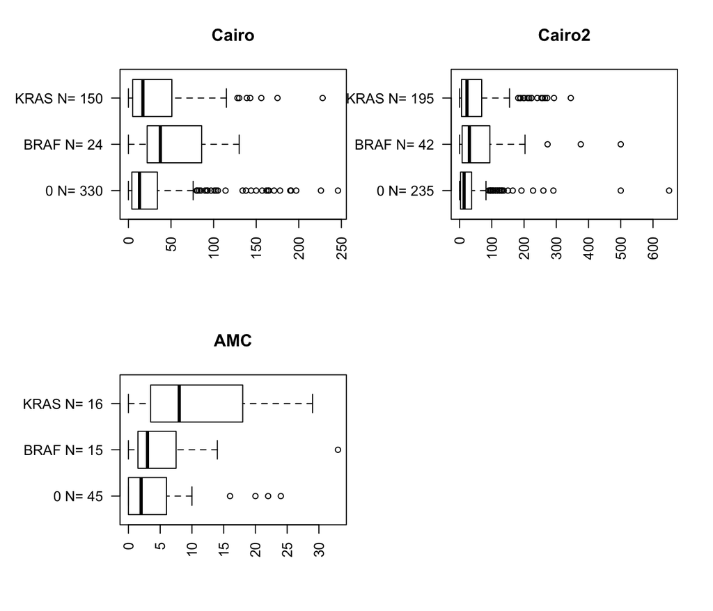

Perform wilcoxon test to see if there is any significant difference in budding between the mutants and WT:

```
##                BRAF         RAS
## CAIRO  0.0002351768 0.041511560
## CAIRO2 0.0112453552 0.003122519
## AMC    0.2921615296 0.002059550
```

This is featured in **Figure 5**

## Splitting Treatment Arms according to KRAS or BRAF

### CAIRO

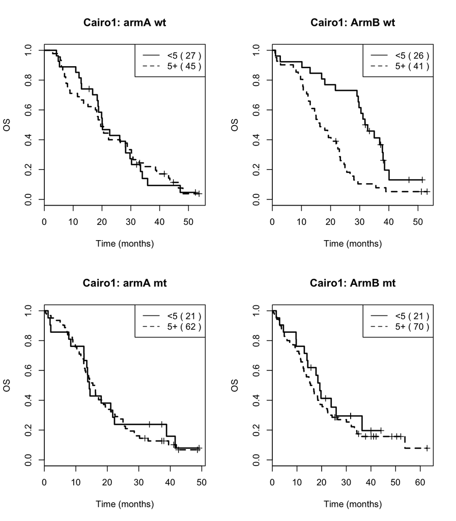

### CAIRO2

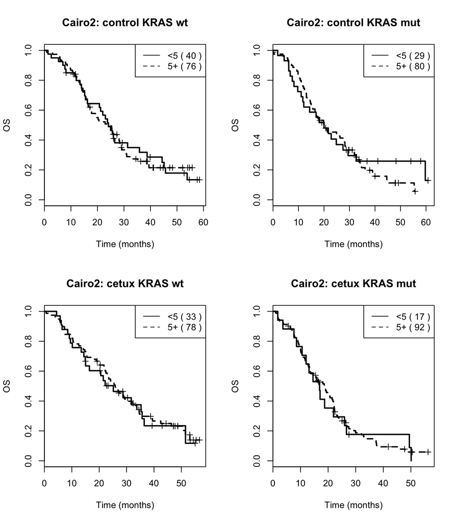

## Rerun cox models:

Determine whether associations are still significant after taking into account Mutation status

### AMC set

```
## Call:
## coxph(formula = ssAMC ~ Sex + stage + KRAS_BRAF + log10(Budding.ITBCC +
##     1), data = AMCClinNew)
##
##   n= 76, number of events= 16
##
##                            coef exp(coef) se(coef)     z Pr(>|z|)
## SexM                     0.3138    1.3686   0.5255 0.597  0.55043
## stageIIB                 2.0865    8.0563   0.7693 2.712  0.00668 **
## KRAS_BRAFTRUE            0.7834    2.1889   0.5474 1.431  0.15239
## log10(Budding.ITBCC + 1) 1.0005    2.7197   0.6424 1.557  0.11935
## ---
## Signif. codes:  0 '***' 0.001 '**' 0.01 '*' 0.05 '.' 0.1 ' ' 1
##
##                          exp(coef) exp(-coef) lower .95 upper .95
## SexM                         1.369     0.7307    0.4886     3.833
## stageIIB                     8.056     0.1241    1.7838    36.385
## KRAS_BRAFTRUE                2.189     0.4568    0.7487     6.400
## log10(Budding.ITBCC + 1)     2.720     0.3677    0.7722     9.579
##
## Concordance= 0.669  (se = 0.074 )
## Rsquare= 0.11   (max possible= 0.823 )
## Likelihood ratio test= 8.89  on 4 df,   p=0.06386
## Wald test            = 8.9  on 4 df,   p=0.06377
## Score (logrank) test = 10.27  on 4 df,   p=0.03606
```

Taking into account KRAS or BRAF mutation, ITBB no longer has a prognostic effect

### CAIRO

```
## Call:
## coxph(formula = ssCai1 ~ KRAS_BRAF + treatment.Arm + Geslacht +
##     log10(Count + 1) + Age, data = Cai1ClinNew)
##
##   n= 313, number of events= 271
##    (191 observations deleted due to missingness)
##
##                        coef exp(coef)  se(coef)      z Pr(>|z|)
## KRAS_BRAF1         0.123126  1.131027  0.126936  0.970   0.3321
## treatment.ArmArmB -0.097281  0.907301  0.123280 -0.789   0.4300
## GeslachtM          0.041541  1.042416  0.126265  0.329   0.7422
## log10(Count + 1)   0.215291  1.240223  0.101418  2.123   0.0338 *
## Age                0.007431  1.007458  0.006472  1.148   0.2509
## ---
## Signif. codes:  0 '***' 0.001 '**' 0.01 '*' 0.05 '.' 0.1 ' ' 1
##
##                   exp(coef) exp(-coef) lower .95 upper .95
## KRAS_BRAF1           1.1310     0.8842    0.8819     1.451
## treatment.ArmArmB    0.9073     1.1022    0.7126     1.155
## GeslachtM            1.0424     0.9593    0.8139     1.335
## log10(Count + 1)     1.2402     0.8063    1.0167     1.513
## Age                  1.0075     0.9926    0.9948     1.020
##
## Concordance= 0.572  (se = 0.02 )
## Rsquare= 0.028   (max possible= 1 )
## Likelihood ratio test= 8.89  on 5 df,   p=0.1136
## Wald test            = 8.9  on 5 df,   p=0.113
## Score (logrank) test = 8.93  on 5 df,   p=0.1118
```

### CAIRO2

```
## Call:
## coxph(formula = ssCai2 ~ KRAS_BRAF + Arm + Sex + log10(no.of.buds +
##     1) + Age, data = Cai2ClinNew)
##
##   n= 430, number of events= 340
##    (42 observations deleted due to missingness)
##
##                           coef exp(coef) se(coef)     z Pr(>|z|)
## KRAS_BRAFTRUE         0.359726  1.432937 0.112461 3.199  0.00138 **
## ArmwCetux             0.156366  1.169255 0.110345 1.417  0.15646
## SexM                  0.114249  1.121031 0.112331 1.017  0.30912
## log10(no.of.buds + 1) 0.076848  1.079878 0.085688 0.897  0.36981
## Age                   0.014836  1.014946 0.006389 2.322  0.02024 *
## ---
## Signif. codes:  0 '***' 0.001 '**' 0.01 '*' 0.05 '.' 0.1 ' ' 1
##
##                       exp(coef) exp(-coef) lower .95 upper .95
## KRAS_BRAFTRUE             1.433     0.6979    1.1495     1.786
## ArmwCetux                 1.169     0.8552    0.9419     1.452
## SexM                      1.121     0.8920    0.8995     1.397
## log10(no.of.buds + 1)     1.080     0.9260    0.9129     1.277
## Age                       1.015     0.9853    1.0023     1.028
##
## Concordance= 0.577  (se = 0.017 )
## Rsquare= 0.05   (max possible= 1 )
## Likelihood ratio test= 22.05  on 5 df,   p=0.0005116
## Wald test            = 21.72  on 5 df,   p=0.0005916
## Score (logrank) test = 21.86  on 5 df,   p=0.0005574
```

KRAS and BRAF mutation, and age are much better explainers of survival than ITBB